# PRÁCTICA CALIFICADA 3

Código: 20200882

Nombres y apellidos: Franco Felipe Hurtado Aguilar

2022-06-01

## PARTE 2

Esta sección se realizará en base al análisis de una base de datos que contiene indicadores de la Encuesta Mundial de Valores.La Encuesta Mundial de Valores (EMV) o World Values Survey (WVS) es un proyecto global de investigación social que explora los valores y opiniones de la gente, cómo estos cambian con el tiempo, y su impacto social y político. Desde 1981 una red mundial de científicos sociales y politólogos llevan a cabo esta investigación, haciendo encuestas nacionales representativas en casi 100 países. La WVS es la única fuente de datos empíricos sobre actitudes y valores humanos que abarca a la mayoría de la población mundial (casi el 90%).

```r
library(rio)
data = import("wvs_VF.rda")
```

### Pregunta 1 (3 puntos). ¿Existe asociación entre las variables de Confianza en las fuerzas armadas (Q65) y confianza en el gobierno nacional (Q71)? Calcule la prueba y medidas de asociación pertinentes

```r
str(data$Q65)
```

```
##  Factor w/ 4 levels "Mucha","Algo",..: 1 3 1 2 3 3 1 4 2 1 ...
```

```r
data$Q65=ordered(data$Q65)
str(data$Q65)
```

```
##  Ord.factor w/ 4 levels "Mucha"<"Algo"<..: 1 3 1 2 3 3 1 4 2 1 ...
```

```r
table(data$Q65)
```

```
##
## Mucha  Algo  Poca  Nada
##   140   362   571   314
```

```r
str(data$Q71)
```

```
##  Factor w/ 4 levels "Mucha","Algo",..: 1 1 3 4 4 3 3 4 4 3 ...
```

```r
data$Q71=ordered(data$Q71)
str(data$Q71)
```

```
##  Ord.factor w/ 4 levels "Mucha"<"Algo"<..: 1 1 3 4 4 3 3 4 4 3 ...
```

```r
table(data$Q71)
```

```
##
## Mucha  Algo  Poca  Nada
##    25   128   432   796
```

Hacemos la tabla de contingencia

```r
tabla1=table(data$Q65,data$Q71)
tabla1
```

```
##
##         Mucha Algo Poca Nada
##   Mucha    11   25   45   58
##   Algo      7   64  133  156
##   Poca      5   30  205  324
##   Nada      2    9   47  250
```

Procedemos a hacer la tabla de porcentajes

```r
prop.table(tabla1,2)
```

```
##
##              Mucha       Algo       Poca       Nada
##   Mucha 0.44000000 0.19531250 0.10465116 0.07360406
##   Algo  0.28000000 0.50000000 0.30930233 0.19796954
##   Poca  0.20000000 0.23437500 0.47674419 0.41116751
##   Nada  0.08000000 0.07031250 0.10930233 0.31725888
```

```r
prop.table(tabla1,2)*100
```

```
##
##             Mucha      Algo      Poca      Nada
##   Mucha 44.000000 19.531250 10.465116  7.360406
##   Algo  28.000000 50.000000 30.930233 19.796954
##   Poca  20.000000 23.437500 47.674419 41.116751
##   Nada   8.000000  7.031250 10.930233 31.725888
```

```r
tabla1.1 = prop.table(tabla1,2)*100
tabla1.1
```

```
##
##             Mucha      Algo      Poca      Nada
##   Mucha 44.000000 19.531250 10.465116  7.360406
##   Algo  28.000000 50.000000 30.930233 19.796954
##   Poca  20.000000 23.437500 47.674419 41.116751
##   Nada   8.000000  7.031250 10.930233 31.725888
```

Hacemos el gráfico de barras

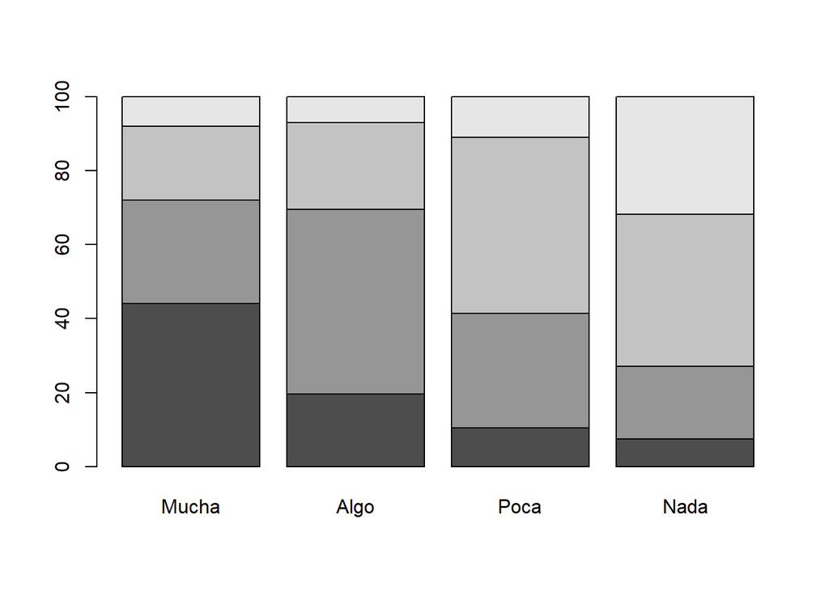

```r
barplot(tabla1.1)
```

En el gráfico de barras podemos ver que los porcentajes de confianza en las fuerzas armadas varían según disminuye la confianza en el gobierno nacional, pero debemos corroborar con la prueba de chi cuadrado.

Nuestro H0=las variables son independientes, mientras que H1=las variables son dependientes.

```r
chisq.test(tabla1)
```

```
##
##  Pearson's Chi-squared test
##
## data:  tabla1
## X-squared = 177.44, df = 9, p-value < 2.2e-16
```

Debido a que el p-value obtenido es menor a 0.05, corresponde rechazar la H0 y por lo tanto podemos afirmar que existe asociación entre el nivel de confianza en las fuerzas armadas y el nivel de confianza en el gobierno, pero necesitamos hallar la intensidad y el sentido de esta asociación. Debido a que son dos variables ordinales, podemos utilizar el test de Gamma.

```r
library(DescTools)
GoodmanKruskalGamma(tabla1)
```

```
## [1] 0.4268329
```

Con un coeficiente de 0.426, podemos determinar que la dependencia entre estas variables es directa y de fuerza media, por lo que afirmamos que mientras más baje el nivel de confianza en el gobierno, más bajará el nivel de confianza en las fuerzas armadas, y de la misma manera aumentará uno cuando el otro también aumente.

### Pregunta 2 (3 puntos).¿Existe asociación entre las personas que han sido víctima de algún delito (Q144) y la evaluación que hacen las personas sobre el impacto que tienen los inmigrantes en el desarrollo del Perú (Q121)? Calcule la prueba y medidas de asociación pertinentes

```r
str(data$Q144)
```

```
##  Factor w/ 2 levels "Si","No": NA 2 2 1 2 2 2 2 2 2 ...
```

```r
table(data$Q144)
```

```
##
##   Si   No
##  279 1118
```

```r
str(data$Q121)
```

```
##  Ord.factor w/ 5 levels "Muy bueno"<"Bueno"<..: 5 3 2 3 2 2 2 3 4 2 ...
```

```r
table(data$Q121)
```

```
##
##        Muy bueno            Bueno Ni bueno ni malo             Malo
##               15              177              647              440
##         Muy Malo
##               91
```

Hacemos la tabla de contingencia.

```r
tabla2= table(data$Q121, data$Q144)
tabla2
```

```
##
##                     Si  No
##   Muy bueno          3  12
##   Bueno             38 139
##   Ni bueno ni malo 133 513
##   Malo              81 359
##   Muy Malo          19  71
```

Procedemos a comprobar la tabla de porcentajes

```r
prop.table(tabla2,2)
```

```
##
##                            Si         No
##   Muy bueno        0.01094891 0.01096892
##   Bueno            0.13868613 0.12705667
##   Ni bueno ni malo 0.48540146 0.46892139
##   Malo             0.29562044 0.32815356
##   Muy Malo         0.06934307 0.06489945
```

```r
prop.table(tabla2,2)*100
```

```
##
##                           Si        No
##   Muy bueno         1.094891  1.096892
##   Bueno            13.868613 12.705667
##   Ni bueno ni malo 48.540146 46.892139
##   Malo             29.562044 32.815356
##   Muy Malo          6.934307  6.489945
```

```r
tabla2.1 = prop.table(tabla2,2)*100
tabla2.1
```

```
##
##                           Si        No
##   Muy bueno         1.094891  1.096892
##   Bueno            13.868613 12.705667
##   Ni bueno ni malo 48.540146 46.892139
##   Malo             29.562044 32.815356
##   Muy Malo          6.934307  6.489945
```

Corroboramos con el barplot.

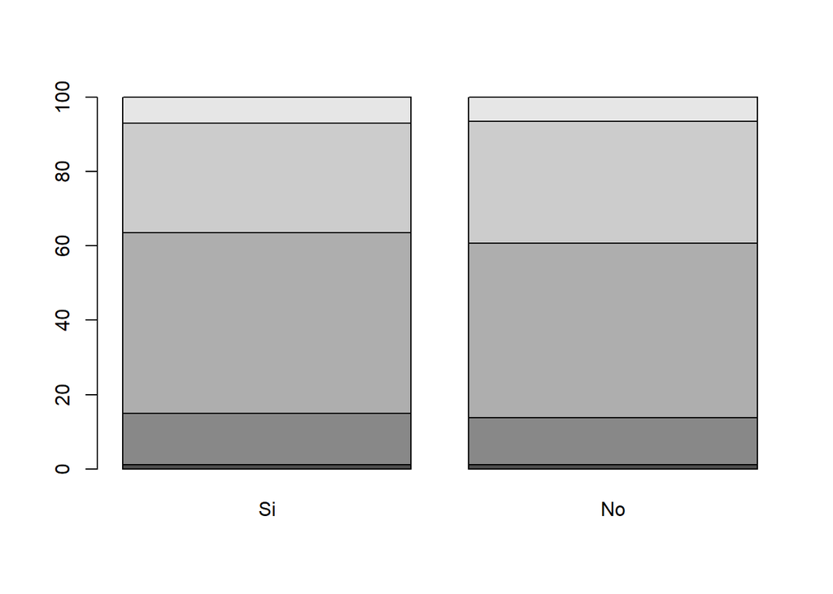

```r
barplot(tabla2.1)
```

La variación en la evaluación de la población sobre cómo afectan los inmigrantes al desarrollo del país no parece variar entre las personas que han sido víctimas de un delito y las que no, pero debemos comprobar con la prueba de chi cuadrado.

```r
chisq.test(tabla2)
```

```
##
##  Pearson's Chi-squared test
##
## data:  tabla2
## X-squared = 1.1419, df = 4, p-value = 0.8876
```

Debido a que el p-value obtenido es mayor a 0.05 debemos aceptar la H0 y por lo tanto confirmamos que no existe asociación entre la evaluación de la población sobre cómo afectan los inmigrantes al desarrollo del Perú y las personas que han sido o no víctimas de un delito en el último año.

```r
str(data$ind_confianza)
```

```
##  num [1:1400] 2.59 5.93 6.67 8.52 9.63 ...
```

```r
str(data$Q262)
```

```
##  num [1:1400] 48 79 82 35 20 58 24 33 62 39 ...
##  - attr(*, "label")= chr "Age"
##  - attr(*, "format.stata")= chr "%9.0f"
##  - attr(*, "labels")= Named num [1:4] -1 -2 -4 -5
##   ..- attr(*, "names")= chr [1:4] "Don't know" "No answer" "Not asked" "Other missing; Multiple answers Mail (EVS) {other missing}"
```

Ya que ambas variables son numéricas, podemos hacer el gráfico de dispersión.

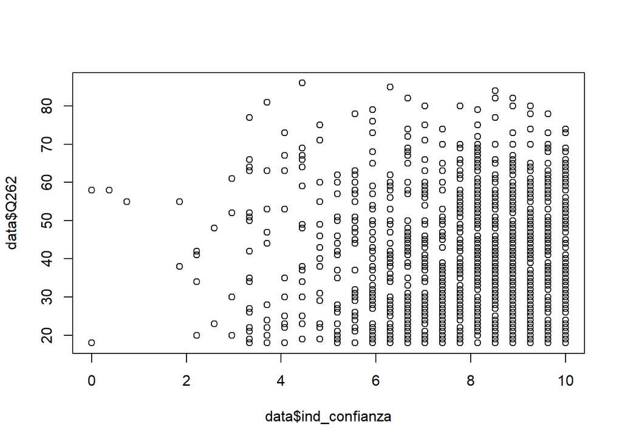

```r
plot(data$ind_confianza, data$Q262)
```